# Optimal Treatment Analysis

## Outcome Variable

**Outcome Variable:** ever_stunted

## Predictor Variables

**Intervention Variable:** feducyrs

**Adjustment Set:**

- arm
- W_mage
- meducyrs
- W_mhtcm
- W_gagebrth
- W_birthwt
- W_birthlen
- single
- delta_W_mage
- delta_meducyrs
- delta_W_mhtcm
- delta_W_gagebrth
- delta_W_birthwt
- delta_W_birthlen
- delta_single

## Stratifying Variables

The analysis was stratified on these variable(s):

- agecat
- studyid
- country

## Data Summary

| agecat | studyid | country | feducyrs | ever_stunted | n_cell | n |
| --- | --- | --- | --- | --- | --- | --- |
| 0-24 months | ki0047075b-MAL-ED | BANGLADESH | High | 0 | 31 | 149 |
| 0-24 months | ki0047075b-MAL-ED | BANGLADESH | High | 1 | 23 | 149 |
| 0-24 months | ki0047075b-MAL-ED | BANGLADESH | Low | 0 | 15 | 149 |
| 0-24 months | ki0047075b-MAL-ED | BANGLADESH | Low | 1 | 25 | 149 |
| 0-24 months | ki0047075b-MAL-ED | BANGLADESH | Medium | 0 | 20 | 149 |
| 0-24 months | ki0047075b-MAL-ED | BANGLADESH | Medium | 1 | 35 | 149 |
| 0-24 months | ki0047075b-MAL-ED | INDIA | High | 0 | 18 | 147 |
| 0-24 months | ki0047075b-MAL-ED | INDIA | High | 1 | 26 | 147 |
| 0-24 months | ki0047075b-MAL-ED | INDIA | Low | 0 | 28 | 147 |
| 0-24 months | ki0047075b-MAL-ED | INDIA | Low | 1 | 31 | 147 |
| 0-24 months | ki0047075b-MAL-ED | INDIA | Medium | 0 | 18 | 147 |
| 0-24 months | ki0047075b-MAL-ED | INDIA | Medium | 1 | 26 | 147 |
| 0-24 months | ki0047075b-MAL-ED | NEPAL | High | 0 | 32 | 98 |
| 0-24 months | ki0047075b-MAL-ED | NEPAL | High | 1 | 10 | 98 |
| 0-24 months | ki0047075b-MAL-ED | NEPAL | Low | 0 | 16 | 98 |
| 0-24 months | ki0047075b-MAL-ED | NEPAL | Low | 1 | 12 | 98 |
| 0-24 months | ki0047075b-MAL-ED | NEPAL | Medium | 0 | 15 | 98 |
| 0-24 months | ki0047075b-MAL-ED | NEPAL | Medium | 1 | 13 | 98 |
| 0-24 months | ki0047075b-MAL-ED | PERU | High | 0 | 45 | 250 |
| 0-24 months | ki0047075b-MAL-ED | PERU | High | 1 | 75 | 250 |
| 0-24 months | ki0047075b-MAL-ED | PERU | Low | 0 | 28 | 250 |
| 0-24 months | ki0047075b-MAL-ED | PERU | Low | 1 | 41 | 250 |
| 0-24 months | ki0047075b-MAL-ED | PERU | Medium | 0 | 20 | 250 |
| 0-24 months | ki0047075b-MAL-ED | PERU | Medium | 1 | 41 | 250 |
| 0-24 months | ki0047075b-MAL-ED | SOUTH AFRICA | High | 0 | 15 | 110 |
| 0-24 months | ki0047075b-MAL-ED | SOUTH AFRICA | High | 1 | 28 | 110 |
| 0-24 months | ki0047075b-MAL-ED | SOUTH AFRICA | Low | 0 | 18 | 110 |
| 0-24 months | ki0047075b-MAL-ED | SOUTH AFRICA | Low | 1 | 19 | 110 |
| 0-24 months | ki0047075b-MAL-ED | SOUTH AFRICA | Medium | 0 | 11 | 110 |
| 0-24 months | ki0047075b-MAL-ED | SOUTH AFRICA | Medium | 1 | 19 | 110 |

[output cut: 330 more lines]

The following strata were considered:

- agecat: 0-24 months, studyid: ki0047075b-MAL-ED, country: BANGLADESH
- agecat: 0-24 months, studyid: ki0047075b-MAL-ED, country: INDIA
- agecat: 0-24 months, studyid: ki0047075b-MAL-ED, country: NEPAL
- agecat: 0-24 months, studyid: ki0047075b-MAL-ED, country: PERU
- agecat: 0-24 months, studyid: ki0047075b-MAL-ED, country: SOUTH AFRICA
- agecat: 0-24 months, studyid: ki0047075b-MAL-ED, country: TANZANIA, UNITED REPUBLIC OF
- agecat: 0-24 months, studyid: ki1000304b-SAS-CompFeed, country: INDIA
- agecat: 0-24 months, studyid: ki1000304b-SAS-FoodSuppl, country: INDIA
- agecat: 0-24 months, studyid: ki1017093b-PROVIDE, country: BANGLADESH
- agecat: 0-24 months, studyid: ki1017093c-NIH-Crypto, country: BANGLADESH
- agecat: 0-24 months, studyid: ki1066203-TanzaniaChild2, country: TANZANIA, UNITED REPUBLIC OF
- agecat: 0-24 months, studyid: ki1113344-GMS-Nepal, country: NEPAL
- agecat: 0-24 months, studyid: ki1119695-PROBIT, country: BELARUS
- agecat: 0-24 months, studyid: ki1126311-ZVITAMBO, country: ZIMBABWE
- agecat: 0-24 months, studyid: ki1135781-COHORTS, country: GUATEMALA
- agecat: 0-24 months, studyid: ki1135781-COHORTS, country: INDIA
- agecat: 0-24 months, studyid: ki1135781-COHORTS, country: PHILIPPINES
- agecat: 0-24 months, studyid: ki1148112-LCNI-5, country: MALAWI
- agecat: 0-24 months, studyid: kiGH5241-JiVitA-3, country: BANGLADESH
- agecat: 0-24 months, studyid: kiGH5241-JiVitA-4, country: BANGLADESH
- agecat: 0-6 months, studyid: ki0047075b-MAL-ED, country: BANGLADESH
- agecat: 0-6 months, studyid: ki0047075b-MAL-ED, country: INDIA
- agecat: 0-6 months, studyid: ki0047075b-MAL-ED, country: NEPAL
- agecat: 0-6 months, studyid: ki0047075b-MAL-ED, country: PERU
- agecat: 0-6 months, studyid: ki0047075b-MAL-ED, country: SOUTH AFRICA
- agecat: 0-6 months, studyid: ki0047075b-MAL-ED, country: TANZANIA, UNITED REPUBLIC OF
- agecat: 0-6 months, studyid: ki1000304b-SAS-CompFeed, country: INDIA
- agecat: 0-6 months, studyid: ki1000304b-SAS-FoodSuppl, country: INDIA
- agecat: 0-6 months, studyid: ki1017093b-PROVIDE, country: BANGLADESH
- agecat: 0-6 months, studyid: ki1017093c-NIH-Crypto, country: BANGLADESH
- agecat: 0-6 months, studyid: ki1066203-TanzaniaChild2, country: TANZANIA, UNITED REPUBLIC OF
- agecat: 0-6 months, studyid: ki1113344-GMS-Nepal, country: NEPAL
- agecat: 0-6 months, studyid: ki1119695-PROBIT, country: BELARUS
- agecat: 0-6 months, studyid: ki1126311-ZVITAMBO, country: ZIMBABWE
- agecat: 0-6 months, studyid: ki1135781-COHORTS, country: GUATEMALA
- agecat: 0-6 months, studyid: ki1135781-COHORTS, country: INDIA
- agecat: 0-6 months, studyid: ki1135781-COHORTS, country: PHILIPPINES
- agecat: 0-6 months, studyid: ki1148112-LCNI-5, country: MALAWI
- agecat: 0-6 months, studyid: kiGH5241-JiVitA-3, country: BANGLADESH
- agecat: 0-6 months, studyid: kiGH5241-JiVitA-4, country: BANGLADESH
- agecat: 6-24 months, studyid: ki0047075b-MAL-ED, country: BANGLADESH
- agecat: 6-24 months, studyid: ki0047075b-MAL-ED, country: INDIA
- agecat: 6-24 months, studyid: ki0047075b-MAL-ED, country: NEPAL
- agecat: 6-24 months, studyid: ki0047075b-MAL-ED, country: PERU
- agecat: 6-24 months, studyid: ki0047075b-MAL-ED, country: SOUTH AFRICA
- agecat: 6-24 months, studyid: ki0047075b-MAL-ED, country: TANZANIA, UNITED REPUBLIC OF
- agecat: 6-24 months, studyid: ki1000304b-SAS-CompFeed, country: INDIA
- agecat: 6-24 months, studyid: ki1000304b-SAS-FoodSuppl, country: INDIA
- agecat: 6-24 months, studyid: ki1017093b-PROVIDE, country: BANGLADESH
- agecat: 6-24 months, studyid: ki1017093c-NIH-Crypto, country: BANGLADESH
- agecat: 6-24 months, studyid: ki1066203-TanzaniaChild2, country: TANZANIA, UNITED REPUBLIC OF
- agecat: 6-24 months, studyid: ki1113344-GMS-Nepal, country: NEPAL
- agecat: 6-24 months, studyid: ki1119695-PROBIT, country: BELARUS
- agecat: 6-24 months, studyid: ki1126311-ZVITAMBO, country: ZIMBABWE
- agecat: 6-24 months, studyid: ki1135781-COHORTS, country: GUATEMALA
- agecat: 6-24 months, studyid: ki1135781-COHORTS, country: INDIA
- agecat: 6-24 months, studyid: ki1135781-COHORTS, country: PHILIPPINES
- agecat: 6-24 months, studyid: ki1148112-LCNI-5, country: MALAWI
- agecat: 6-24 months, studyid: kiGH5241-JiVitA-3, country: BANGLADESH
- agecat: 6-24 months, studyid: kiGH5241-JiVitA-4, country: BANGLADESH

### Dropped Strata

Some strata were dropped due to rare outcomes:

- agecat: 0-24 months, studyid: ki0047075b-MAL-ED, country: TANZANIA, UNITED REPUBLIC OF
- agecat: 0-6 months, studyid: ki0047075b-MAL-ED, country: NEPAL
- agecat: 6-24 months, studyid: ki0047075b-MAL-ED, country: NEPAL
- agecat: 6-24 months, studyid: ki0047075b-MAL-ED, country: TANZANIA, UNITED REPUBLIC OF

## Methods Detail

We’re interested in the causal parameters $E[Y_a]$ for all values of $a \in \mathcal{A}$. These parameters represent the mean outcome if, possibly contrary to fact, we intervened to set all units to have $A=a$. Under the randomization and positivity assumptions, these are identified by the statistical parameters $\psi_a=E_W[E_{Y|A,W}(Y|A=a,W)]$. In addition, we’re interested in the mean of $Y$, $E[Y]$ under no intervention (the observed mean). We will estimate these parameters by using SuperLearner to fit the relevant likelihood factors – $E_{Y|A,W}(Y|A=a,W)$ and $p(A=a|W)$, and then updating our likelihood fit using a joint TMLE.

For unadjusted analyses ($W=\{\}$), initial likelihoods were estimated using Lrnr_glm to estimate the simple $E(Y|A)$ and Lrnr_mean to estimate $p(A)$. For adjusted analyses, a small library containing Lrnr_glmnet, Lrnr_xgboost, and Lrnr_mean was used.

Having estimated these parameters, we will then use the delta method to estimate relative risks and attributable risks relative to a prespecified baseline level of $A$.

# Results Detail

## Results Plots

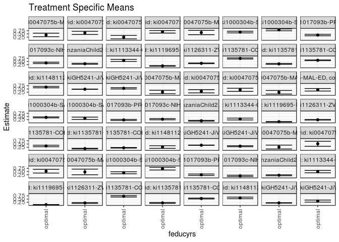

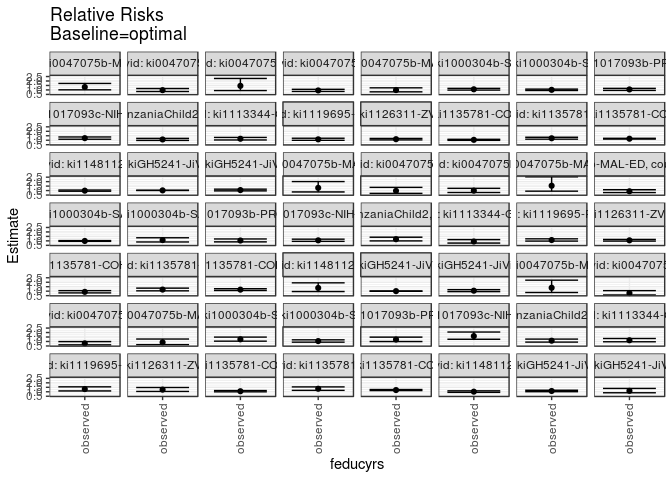

## Results Table

### Parameter: TSM

| agecat | studyid | country | intervention_level | baseline_level | estimate | ci_lower | ci_upper |
| --- | --- | --- | --- | --- | --- | --- | --- |
| 0-24 months | ki0047075b-MAL-ED | BANGLADESH | optimal | NA | 0.4208523 | 0.2828521 | 0.5588524 |
| 0-24 months | ki0047075b-MAL-ED | INDIA | optimal | NA | 0.5777070 | 0.4526136 | 0.7028004 |
| 0-24 months | ki0047075b-MAL-ED | NEPAL | optimal | NA | 0.2450902 | 0.1108735 | 0.3793069 |
| 0-24 months | ki0047075b-MAL-ED | PERU | optimal | NA | 0.6650870 | 0.5655346 | 0.7646395 |
| 0-24 months | ki0047075b-MAL-ED | SOUTH AFRICA | optimal | NA | 0.6080691 | 0.4390632 | 0.7770751 |
| 0-24 months | ki1000304b-SAS-CompFeed | INDIA | optimal | NA | 0.6435580 | 0.5798776 | 0.7072383 |
| 0-24 months | ki1000304b-SAS-FoodSuppl | INDIA | optimal | NA | 0.8180547 | 0.7461810 | 0.8899284 |
| 0-24 months | ki1017093b-PROVIDE | BANGLADESH | optimal | NA | 0.4106847 | 0.3544277 | 0.4669417 |
| 0-24 months | ki1017093c-NIH-Crypto | BANGLADESH | optimal | NA | 0.3865570 | 0.3343091 | 0.4388048 |
| 0-24 months | ki1066203-TanzaniaChild2 | TANZANIA, UNITED REPUBLIC OF | optimal | NA | 0.3183792 | 0.2809248 | 0.3558335 |
| 0-24 months | ki1113344-GMS-Nepal | NEPAL | optimal | NA | 0.5792075 | 0.4980978 | 0.6603173 |
| 0-24 months | ki1119695-PROBIT | BELARUS | optimal | NA | 0.1498547 | 0.1282989 | 0.1714104 |
| 0-24 months | ki1126311-ZVITAMBO | ZIMBABWE | optimal | NA | 0.3509671 | 0.3239196 | 0.3780146 |
| 0-24 months | ki1135781-COHORTS | GUATEMALA | optimal | NA | 0.7330599 | 0.6864810 | 0.7796387 |
| 0-24 months | ki1135781-COHORTS | INDIA | optimal | NA | 0.3091750 | 0.2746065 | 0.3437434 |
| 0-24 months | ki1135781-COHORTS | PHILIPPINES | optimal | NA | 0.5892764 | 0.5603619 | 0.6181909 |
| 0-24 months | ki1148112-LCNI-5 | MALAWI | optimal | NA | 0.6446910 | 0.5914832 | 0.6978987 |
| 0-24 months | kiGH5241-JiVitA-3 | BANGLADESH | optimal | NA | 0.4818608 | 0.4709199 | 0.4928016 |
| 0-24 months | kiGH5241-JiVitA-4 | BANGLADESH | optimal | NA | 0.5497576 | 0.4961990 | 0.6033162 |
| 0-6 months | ki0047075b-MAL-ED | BANGLADESH | optimal | NA | 0.2629696 | 0.1267690 | 0.3991702 |
| 0-6 months | ki0047075b-MAL-ED | INDIA | optimal | NA | 0.3178874 | 0.1898021 | 0.4459727 |
| 0-6 months | ki0047075b-MAL-ED | PERU | optimal | NA | 0.4329133 | 0.3103707 | 0.5554560 |
| 0-6 months | ki0047075b-MAL-ED | SOUTH AFRICA | optimal | NA | 0.2422205 | 0.1019429 | 0.3824981 |
| 0-6 months | ki0047075b-MAL-ED | TANZANIA, UNITED REPUBLIC OF | optimal | NA | 0.4364141 | 0.3375467 | 0.5352815 |
| 0-6 months | ki1000304b-SAS-CompFeed | INDIA | optimal | NA | 0.4297403 | 0.3901030 | 0.4693777 |
| 0-6 months | ki1000304b-SAS-FoodSuppl | INDIA | optimal | NA | 0.3580864 | 0.2687745 | 0.4473982 |
| 0-6 months | ki1017093b-PROVIDE | BANGLADESH | optimal | NA | 0.2298426 | 0.1836527 | 0.2760325 |
| 0-6 months | ki1017093c-NIH-Crypto | BANGLADESH | optimal | NA | 0.2854098 | 0.2400407 | 0.3307789 |
| 0-6 months | ki1066203-TanzaniaChild2 | TANZANIA, UNITED REPUBLIC OF | optimal | NA | 0.1644672 | 0.1326246 | 0.1963098 |
| 0-6 months | ki1113344-GMS-Nepal | NEPAL | optimal | NA | 0.2999646 | 0.2281398 | 0.3717895 |
| 0-6 months | ki1119695-PROBIT | BELARUS | optimal | NA | 0.0894101 | 0.0741324 | 0.1046878 |
| 0-6 months | ki1126311-ZVITAMBO | ZIMBABWE | optimal | NA | 0.2414141 | 0.2192126 | 0.2636157 |
| 0-6 months | ki1135781-COHORTS | GUATEMALA | optimal | NA | 0.3460357 | 0.2893531 | 0.4027183 |
| 0-6 months | ki1135781-COHORTS | INDIA | optimal | NA | 0.1391308 | 0.1146825 | 0.1635792 |
| 0-6 months | ki1135781-COHORTS | PHILIPPINES | optimal | NA | 0.2035117 | 0.1819607 | 0.2250628 |
| 0-6 months | ki1148112-LCNI-5 | MALAWI | optimal | NA | 0.2614154 | 0.1577160 | 0.3651148 |
| 0-6 months | kiGH5241-JiVitA-3 | BANGLADESH | optimal | NA | 0.4065355 | 0.3964652 | 0.4166059 |
| 0-6 months | kiGH5241-JiVitA-4 | BANGLADESH | optimal | NA | 0.3288544 | 0.2899490 | 0.3677598 |
| 6-24 months | ki0047075b-MAL-ED | BANGLADESH | optimal | NA | 0.2605685 | 0.1090283 | 0.4121087 |
| 6-24 months | ki0047075b-MAL-ED | INDIA | optimal | NA | 0.5175423 | 0.3217830 | 0.7133015 |
| 6-24 months | ki0047075b-MAL-ED | PERU | optimal | NA | 0.5256266 | 0.3780674 | 0.6731858 |
| 6-24 months | ki0047075b-MAL-ED | SOUTH AFRICA | optimal | NA | 0.4672408 | 0.2485074 | 0.6859743 |
| 6-24 months | ki1000304b-SAS-CompFeed | INDIA | optimal | NA | 0.4044725 | 0.3266739 | 0.4822712 |
| 6-24 months | ki1000304b-SAS-FoodSuppl | INDIA | optimal | NA | 0.7238408 | 0.6169493 | 0.8307324 |
| 6-24 months | ki1017093b-PROVIDE | BANGLADESH | optimal | NA | 0.2468196 | 0.1863038 | 0.3073353 |
| 6-24 months | ki1017093c-NIH-Crypto | BANGLADESH | optimal | NA | 0.1640976 | 0.1150900 | 0.2131053 |
| 6-24 months | ki1066203-TanzaniaChild2 | TANZANIA, UNITED REPUBLIC OF | optimal | NA | 0.2082991 | 0.1706989 | 0.2458993 |
| 6-24 months | ki1113344-GMS-Nepal | NEPAL | optimal | NA | 0.4950494 | 0.4022324 | 0.5878664 |
| 6-24 months | ki1119695-PROBIT | BELARUS | optimal | NA | 0.0584517 | 0.0431569 | 0.0737465 |
| 6-24 months | ki1126311-ZVITAMBO | ZIMBABWE | optimal | NA | 0.1956681 | 0.1603563 | 0.2309799 |
| 6-24 months | ki1135781-COHORTS | GUATEMALA | optimal | NA | 0.7170409 | 0.6611779 | 0.7729039 |
| 6-24 months | ki1135781-COHORTS | INDIA | optimal | NA | 0.1988749 | 0.1637216 | 0.2340281 |
| 6-24 months | ki1135781-COHORTS | PHILIPPINES | optimal | NA | 0.5425179 | 0.5080621 | 0.5769737 |
| 6-24 months | ki1148112-LCNI-5 | MALAWI | optimal | NA | 0.5898903 | 0.5280055 | 0.6517751 |
| 6-24 months | kiGH5241-JiVitA-3 | BANGLADESH | optimal | NA | 0.1987577 | 0.1823170 | 0.2151985 |
| 6-24 months | kiGH5241-JiVitA-4 | BANGLADESH | optimal | NA | 0.3400604 | 0.2605587 | 0.4195621 |

### Parameter: E(Y)

| agecat | studyid | country | intervention_level | baseline_level | estimate | ci_lower | ci_upper |
| --- | --- | --- | --- | --- | --- | --- | --- |
| 0-24 months | ki0047075b-MAL-ED | BANGLADESH | observed | NA | 0.5570470 | 0.4770190 | 0.6370750 |
| 0-24 months | ki0047075b-MAL-ED | INDIA | observed | NA | 0.5646259 | 0.4842023 | 0.6450494 |
| 0-24 months | ki0047075b-MAL-ED | NEPAL | observed | NA | 0.3571429 | 0.2617885 | 0.4524972 |
| 0-24 months | ki0047075b-MAL-ED | PERU | observed | NA | 0.6280000 | 0.5679657 | 0.6880343 |
| 0-24 months | ki0047075b-MAL-ED | SOUTH AFRICA | observed | NA | 0.6000000 | 0.5080312 | 0.6919688 |
| 0-24 months | ki1000304b-SAS-CompFeed | INDIA | observed | NA | 0.6908497 | 0.6505448 | 0.7311545 |
| 0-24 months | ki1000304b-SAS-FoodSuppl | INDIA | observed | NA | 0.8277512 | 0.7915095 | 0.8639929 |
| 0-24 months | ki1017093b-PROVIDE | BANGLADESH | observed | NA | 0.4342857 | 0.3975409 | 0.4710305 |
| 0-24 months | ki1017093c-NIH-Crypto | BANGLADESH | observed | NA | 0.4775726 | 0.4419904 | 0.5131548 |
| 0-24 months | ki1066203-TanzaniaChild2 | TANZANIA, UNITED REPUBLIC OF | observed | NA | 0.3466219 | 0.3275107 | 0.3657331 |
| 0-24 months | ki1113344-GMS-Nepal | NEPAL | observed | NA | 0.6755408 | 0.6380799 | 0.7130017 |
| 0-24 months | ki1119695-PROBIT | BELARUS | observed | NA | 0.1652568 | 0.1463320 | 0.1841817 |
| 0-24 months | ki1126311-ZVITAMBO | ZIMBABWE | observed | NA | 0.3929015 | 0.3847209 | 0.4010821 |
| 0-24 months | ki1135781-COHORTS | GUATEMALA | observed | NA | 0.7672000 | 0.7437624 | 0.7906376 |
| 0-24 months | ki1135781-COHORTS | INDIA | observed | NA | 0.3780235 | 0.3530310 | 0.4030160 |
| 0-24 months | ki1135781-COHORTS | PHILIPPINES | observed | NA | 0.6899306 | 0.6730355 | 0.7068256 |
| 0-24 months | ki1148112-LCNI-5 | MALAWI | observed | NA | 0.6371464 | 0.6040748 | 0.6702180 |
| 0-24 months | kiGH5241-JiVitA-3 | BANGLADESH | observed | NA | 0.4915971 | 0.4836947 | 0.4994995 |
| 0-24 months | kiGH5241-JiVitA-4 | BANGLADESH | observed | NA | 0.5795971 | 0.5574204 | 0.6017738 |
| 0-6 months | ki0047075b-MAL-ED | BANGLADESH | observed | NA | 0.3422819 | 0.2658404 | 0.4187234 |
| 0-6 months | ki0047075b-MAL-ED | INDIA | observed | NA | 0.3061224 | 0.2313639 | 0.3808810 |
| 0-6 months | ki0047075b-MAL-ED | PERU | observed | NA | 0.4280000 | 0.3665434 | 0.4894566 |
| 0-6 months | ki0047075b-MAL-ED | SOUTH AFRICA | observed | NA | 0.3727273 | 0.2819539 | 0.4635007 |
| 0-6 months | ki0047075b-MAL-ED | TANZANIA, UNITED REPUBLIC OF | observed | NA | 0.4009434 | 0.3348159 | 0.4670709 |
| 0-6 months | ki1000304b-SAS-CompFeed | INDIA | observed | NA | 0.4250164 | 0.3969651 | 0.4530677 |
| 0-6 months | ki1000304b-SAS-FoodSuppl | INDIA | observed | NA | 0.3894231 | 0.3425088 | 0.4363374 |
| 0-6 months | ki1017093b-PROVIDE | BANGLADESH | observed | NA | 0.2385714 | 0.2069753 | 0.2701675 |
| 0-6 months | ki1017093c-NIH-Crypto | BANGLADESH | observed | NA | 0.3021108 | 0.2694011 | 0.3348205 |
| 0-6 months | ki1066203-TanzaniaChild2 | TANZANIA, UNITED REPUBLIC OF | observed | NA | 0.1951322 | 0.1792173 | 0.2110471 |
| 0-6 months | ki1113344-GMS-Nepal | NEPAL | observed | NA | 0.2778702 | 0.2420275 | 0.3137129 |
| 0-6 months | ki1119695-PROBIT | BELARUS | observed | NA | 0.0977315 | 0.0847284 | 0.1107345 |
| 0-6 months | ki1126311-ZVITAMBO | ZIMBABWE | observed | NA | 0.2559789 | 0.2486637 | 0.2632941 |
| 0-6 months | ki1135781-COHORTS | GUATEMALA | observed | NA | 0.3196078 | 0.2909760 | 0.3482397 |
| 0-6 months | ki1135781-COHORTS | INDIA | observed | NA | 0.1639690 | 0.1447117 | 0.1832264 |
| 0-6 months | ki1135781-COHORTS | PHILIPPINES | observed | NA | 0.2381944 | 0.2226342 | 0.2537546 |
| 0-6 months | ki1148112-LCNI-5 | MALAWI | observed | NA | 0.3558052 | 0.2982716 | 0.4133389 |
| 0-6 months | kiGH5241-JiVitA-3 | BANGLADESH | observed | NA | 0.4088773 | 0.4013389 | 0.4164158 |
| 0-6 months | kiGH5241-JiVitA-4 | BANGLADESH | observed | NA | 0.3464052 | 0.3252865 | 0.3675239 |
| 6-24 months | ki0047075b-MAL-ED | BANGLADESH | observed | NA | 0.3595506 | 0.2592902 | 0.4598109 |
| 6-24 months | ki0047075b-MAL-ED | INDIA | observed | NA | 0.4042553 | 0.3045164 | 0.5039942 |
| 6-24 months | ki0047075b-MAL-ED | PERU | observed | NA | 0.4132231 | 0.3251210 | 0.5013252 |
| 6-24 months | ki0047075b-MAL-ED | SOUTH AFRICA | observed | NA | 0.4237288 | 0.2965568 | 0.5509008 |
| 6-24 months | ki1000304b-SAS-CompFeed | INDIA | observed | NA | 0.5024631 | 0.4586872 | 0.5462389 |
| 6-24 months | ki1000304b-SAS-FoodSuppl | INDIA | observed | NA | 0.7572016 | 0.7031798 | 0.8112234 |
| 6-24 months | ki1017093b-PROVIDE | BANGLADESH | observed | NA | 0.2997812 | 0.2577294 | 0.3418330 |
| 6-24 months | ki1017093c-NIH-Crypto | BANGLADESH | observed | NA | 0.2628458 | 0.2244546 | 0.3012371 |
| 6-24 months | ki1066203-TanzaniaChild2 | TANZANIA, UNITED REPUBLIC OF | observed | NA | 0.2263323 | 0.2057897 | 0.2468748 |
| 6-24 months | ki1113344-GMS-Nepal | NEPAL | observed | NA | 0.5623529 | 0.5151323 | 0.6095736 |
| 6-24 months | ki1119695-PROBIT | BELARUS | observed | NA | 0.0761786 | 0.0621943 | 0.0901630 |
| 6-24 months | ki1126311-ZVITAMBO | ZIMBABWE | observed | NA | 0.2426433 | 0.2330974 | 0.2521891 |
| 6-24 months | ki1135781-COHORTS | GUATEMALA | observed | NA | 0.7617329 | 0.7327499 | 0.7907158 |
| 6-24 months | ki1135781-COHORTS | INDIA | observed | NA | 0.2663274 | 0.2410848 | 0.2915700 |
| 6-24 months | ki1135781-COHORTS | PHILIPPINES | observed | NA | 0.6482312 | 0.6273346 | 0.6691278 |
| 6-24 months | ki1148112-LCNI-5 | MALAWI | observed | NA | 0.5983027 | 0.5621404 | 0.6344650 |
| 6-24 months | kiGH5241-JiVitA-3 | BANGLADESH | observed | NA | 0.2163973 | 0.2069603 | 0.2258344 |
| 6-24 months | kiGH5241-JiVitA-4 | BANGLADESH | observed | NA | 0.3764535 | 0.3511984 | 0.4017086 |

### Parameter: RR

| agecat | studyid | country | intervention_level | baseline_level | estimate | ci_lower | ci_upper |
| --- | --- | --- | --- | --- | --- | --- | --- |
| 0-24 months | ki0047075b-MAL-ED | BANGLADESH | observed | optimal | 1.3236165 | 1.0125987 | 1.7301628 |
| 0-24 months | ki0047075b-MAL-ED | INDIA | observed | optimal | 0.9773568 | 0.8256882 | 1.1568849 |
| 0-24 months | ki0047075b-MAL-ED | NEPAL | observed | optimal | 1.4571894 | 0.9294437 | 2.2845934 |
| 0-24 months | ki0047075b-MAL-ED | PERU | observed | optimal | 0.9442373 | 0.8309641 | 1.0729515 |
| 0-24 months | ki0047075b-MAL-ED | SOUTH AFRICA | observed | optimal | 0.9867299 | 0.7886973 | 1.2344862 |
| 0-24 months | ki1000304b-SAS-CompFeed | INDIA | observed | optimal | 1.0734848 | 0.9800187 | 1.1758649 |
| 0-24 months | ki1000304b-SAS-FoodSuppl | INDIA | observed | optimal | 1.0118531 | 0.9397949 | 1.0894364 |
| 0-24 months | ki1017093b-PROVIDE | BANGLADESH | observed | optimal | 1.0574676 | 0.9491059 | 1.1782012 |
| 0-24 months | ki1017093c-NIH-Crypto | BANGLADESH | observed | optimal | 1.2354519 | 1.1147746 | 1.3691929 |
| 0-24 months | ki1066203-TanzaniaChild2 | TANZANIA, UNITED REPUBLIC OF | observed | optimal | 1.0887079 | 0.9830883 | 1.2056749 |
| 0-24 months | ki1113344-GMS-Nepal | NEPAL | observed | optimal | 1.1663190 | 1.0336180 | 1.3160569 |
| 0-24 months | ki1119695-PROBIT | BELARUS | observed | optimal | 1.1027808 | 0.9940517 | 1.2234027 |
| 0-24 months | ki1126311-ZVITAMBO | ZIMBABWE | observed | optimal | 1.1194825 | 1.0398103 | 1.2052592 |
| 0-24 months | ki1135781-COHORTS | GUATEMALA | observed | optimal | 1.0465721 | 0.9913779 | 1.1048392 |
| 0-24 months | ki1135781-COHORTS | INDIA | observed | optimal | 1.2226847 | 1.1218253 | 1.3326119 |
| 0-24 months | ki1135781-COHORTS | PHILIPPINES | observed | optimal | 1.1708098 | 1.1274905 | 1.2157934 |
| 0-24 months | ki1148112-LCNI-5 | MALAWI | observed | optimal | 0.9882973 | 0.9249928 | 1.0559343 |
| 0-24 months | kiGH5241-JiVitA-3 | BANGLADESH | observed | optimal | 1.0202057 | 1.0040928 | 1.0365771 |
| 0-24 months | kiGH5241-JiVitA-4 | BANGLADESH | observed | optimal | 1.0542777 | 0.9640398 | 1.1529622 |
| 0-6 months | ki0047075b-MAL-ED | BANGLADESH | observed | optimal | 1.3016024 | 0.8451411 | 2.0045987 |
| 0-6 months | ki0047075b-MAL-ED | INDIA | observed | optimal | 0.9629902 | 0.6828664 | 1.3580257 |
| 0-6 months | ki0047075b-MAL-ED | PERU | observed | optimal | 0.9886505 | 0.7830973 | 1.2481588 |
| 0-6 months | ki0047075b-MAL-ED | SOUTH AFRICA | observed | optimal | 1.5387933 | 0.9326867 | 2.5387782 |
| 0-6 months | ki0047075b-MAL-ED | TANZANIA, UNITED REPUBLIC OF | observed | optimal | 0.9187223 | 0.7733274 | 1.0914532 |
| 0-6 months | ki1000304b-SAS-CompFeed | INDIA | observed | optimal | 0.9890074 | 0.9451758 | 1.0348717 |
| 0-6 months | ki1000304b-SAS-FoodSuppl | INDIA | observed | optimal | 1.0875116 | 0.8777974 | 1.3473285 |
| 0-6 months | ki1017093b-PROVIDE | BANGLADESH | observed | optimal | 1.0379775 | 0.8882384 | 1.2129595 |
| 0-6 months | ki1017093c-NIH-Crypto | BANGLADESH | observed | optimal | 1.0585159 | 0.9424630 | 1.1888594 |
| 0-6 months | ki1066203-TanzaniaChild2 | TANZANIA, UNITED REPUBLIC OF | observed | optimal | 1.1864504 | 0.9980093 | 1.4104724 |
| 0-6 months | ki1113344-GMS-Nepal | NEPAL | observed | optimal | 0.9263433 | 0.7523390 | 1.1405919 |
| 0-6 months | ki1119695-PROBIT | BELARUS | observed | optimal | 1.0930696 | 0.9723348 | 1.2287960 |
| 0-6 months | ki1126311-ZVITAMBO | ZIMBABWE | observed | optimal | 1.0603311 | 0.9717041 | 1.1570416 |
| 0-6 months | ki1135781-COHORTS | GUATEMALA | observed | optimal | 0.9236268 | 0.8054070 | 1.0591991 |
| 0-6 months | ki1135781-COHORTS | INDIA | observed | optimal | 1.1785239 | 1.0360093 | 1.3406431 |
| 0-6 months | ki1135781-COHORTS | PHILIPPINES | observed | optimal | 1.1704211 | 1.0768205 | 1.2721578 |
| 0-6 months | ki1148112-LCNI-5 | MALAWI | observed | optimal | 1.3610721 | 0.9592623 | 1.9311895 |
| 0-6 months | kiGH5241-JiVitA-3 | BANGLADESH | observed | optimal | 1.0057604 | 0.9895992 | 1.0221856 |
| 0-6 months | kiGH5241-JiVitA-4 | BANGLADESH | observed | optimal | 1.0533696 | 0.9498956 | 1.1681152 |
| 6-24 months | ki0047075b-MAL-ED | BANGLADESH | observed | optimal | 1.3798698 | 0.8528045 | 2.2326813 |
| 6-24 months | ki0047075b-MAL-ED | INDIA | observed | optimal | 0.7811059 | 0.5744769 | 1.0620557 |
| 6-24 months | ki0047075b-MAL-ED | PERU | observed | optimal | 0.7861534 | 0.6260156 | 0.9872552 |
| 6-24 months | ki0047075b-MAL-ED | SOUTH AFRICA | observed | optimal | 0.9068745 | 0.6467786 | 1.2715656 |
| 6-24 months | ki1000304b-SAS-CompFeed | INDIA | observed | optimal | 1.2422674 | 1.0374482 | 1.4875233 |
| 6-24 months | ki1000304b-SAS-FoodSuppl | INDIA | observed | optimal | 1.0460886 | 0.9247492 | 1.1833494 |
| 6-24 months | ki1017093b-PROVIDE | BANGLADESH | observed | optimal | 1.2145761 | 0.9931170 | 1.4854193 |
| 6-24 months | ki1017093c-NIH-Crypto | BANGLADESH | observed | optimal | 1.6017652 | 1.2481004 | 2.0556453 |
| 6-24 months | ki1066203-TanzaniaChild2 | TANZANIA, UNITED REPUBLIC OF | observed | optimal | 1.0865736 | 0.9329667 | 1.2654710 |
| 6-24 months | ki1113344-GMS-Nepal | NEPAL | observed | optimal | 1.1359532 | 0.9673084 | 1.3340002 |
| 6-24 months | ki1119695-PROBIT | BELARUS | observed | optimal | 1.3032751 | 1.0943871 | 1.5520340 |
| 6-24 months | ki1126311-ZVITAMBO | ZIMBABWE | observed | optimal | 1.2400759 | 1.0409993 | 1.4772231 |
| 6-24 months | ki1135781-COHORTS | GUATEMALA | observed | optimal | 1.0623283 | 0.9969050 | 1.1320451 |
| 6-24 months | ki1135781-COHORTS | INDIA | observed | optimal | 1.3391707 | 1.1591951 | 1.5470892 |
| 6-24 months | ki1135781-COHORTS | PHILIPPINES | observed | optimal | 1.1948568 | 1.1378910 | 1.2546745 |
| 6-24 months | ki1148112-LCNI-5 | MALAWI | observed | optimal | 1.0142609 | 0.9337209 | 1.1017480 |
| 6-24 months | kiGH5241-JiVitA-3 | BANGLADESH | observed | optimal | 1.0887491 | 1.0138959 | 1.1691286 |
| 6-24 months | kiGH5241-JiVitA-4 | BANGLADESH | observed | optimal | 1.1070196 | 0.8918720 | 1.3740674 |

### Parameter: PAR

| agecat | studyid | country | intervention_level | baseline_level | estimate | ci_lower | ci_upper |
| --- | --- | --- | --- | --- | --- | --- | --- |
| 0-24 months | ki0047075b-MAL-ED | BANGLADESH | optimal | NA | 0.1361947 | 0.0256425 | 0.2467469 |
| 0-24 months | ki0047075b-MAL-ED | INDIA | optimal | NA | -0.0130812 | -0.1104490 | 0.0842866 |
| 0-24 months | ki0047075b-MAL-ED | NEPAL | optimal | NA | 0.1120526 | 0.0010715 | 0.2230338 |
| 0-24 months | ki0047075b-MAL-ED | PERU | optimal | NA | -0.0370870 | -0.1217076 | 0.0475336 |
| 0-24 months | ki0047075b-MAL-ED | SOUTH AFRICA | optimal | NA | -0.0080691 | -0.1443550 | 0.1282167 |
| 0-24 months | ki1000304b-SAS-CompFeed | INDIA | optimal | NA | 0.0472917 | -0.0118906 | 0.1064740 |
| 0-24 months | ki1000304b-SAS-FoodSuppl | INDIA | optimal | NA | 0.0096965 | -0.0507178 | 0.0701109 |
| 0-24 months | ki1017093b-PROVIDE | BANGLADESH | optimal | NA | 0.0236010 | -0.0208527 | 0.0680548 |
| 0-24 months | ki1017093c-NIH-Crypto | BANGLADESH | optimal | NA | 0.0910156 | 0.0516598 | 0.1303714 |
| 0-24 months | ki1066203-TanzaniaChild2 | TANZANIA, UNITED REPUBLIC OF | optimal | NA | 0.0282428 | -0.0042311 | 0.0607166 |
| 0-24 months | ki1113344-GMS-Nepal | NEPAL | optimal | NA | 0.0963332 | 0.0269464 | 0.1657201 |
| 0-24 months | ki1119695-PROBIT | BELARUS | optimal | NA | 0.0154022 | -0.0004866 | 0.0312909 |
| 0-24 months | ki1126311-ZVITAMBO | ZIMBABWE | optimal | NA | 0.0419344 | 0.0160241 | 0.0678448 |
| 0-24 months | ki1135781-COHORTS | GUATEMALA | optimal | NA | 0.0341401 | -0.0055373 | 0.0738176 |
| 0-24 months | ki1135781-COHORTS | INDIA | optimal | NA | 0.0688485 | 0.0421293 | 0.0955678 |
| 0-24 months | ki1135781-COHORTS | PHILIPPINES | optimal | NA | 0.1006542 | 0.0788203 | 0.1224880 |
| 0-24 months | ki1148112-LCNI-5 | MALAWI | optimal | NA | -0.0075446 | -0.0502083 | 0.0351191 |
| 0-24 months | kiGH5241-JiVitA-3 | BANGLADESH | optimal | NA | 0.0097363 | 0.0020647 | 0.0174079 |
| 0-24 months | kiGH5241-JiVitA-4 | BANGLADESH | optimal | NA | 0.0298396 | -0.0193617 | 0.0790409 |
| 0-6 months | ki0047075b-MAL-ED | BANGLADESH | optimal | NA | 0.0793123 | -0.0326932 | 0.1913177 |
| 0-6 months | ki0047075b-MAL-ED | INDIA | optimal | NA | -0.0117650 | -0.1208100 | 0.0972801 |
| 0-6 months | ki0047075b-MAL-ED | PERU | optimal | NA | -0.0049133 | -0.1058755 | 0.0960488 |
| 0-6 months | ki0047075b-MAL-ED | SOUTH AFRICA | optimal | NA | 0.1305068 | 0.0083789 | 0.2526346 |
| 0-6 months | ki0047075b-MAL-ED | TANZANIA, UNITED REPUBLIC OF | optimal | NA | -0.0354707 | -0.1103112 | 0.0393697 |
| 0-6 months | ki1000304b-SAS-CompFeed | INDIA | optimal | NA | -0.0047240 | -0.0243159 | 0.0148680 |
| 0-6 months | ki1000304b-SAS-FoodSuppl | INDIA | optimal | NA | 0.0313367 | -0.0453380 | 0.1080114 |
| 0-6 months | ki1017093b-PROVIDE | BANGLADESH | optimal | NA | 0.0087288 | -0.0271367 | 0.0445943 |
| 0-6 months | ki1017093c-NIH-Crypto | BANGLADESH | optimal | NA | 0.0167010 | -0.0164875 | 0.0498896 |
| 0-6 months | ki1066203-TanzaniaChild2 | TANZANIA, UNITED REPUBLIC OF | optimal | NA | 0.0306650 | 0.0021904 | 0.0591395 |
| 0-6 months | ki1113344-GMS-Nepal | NEPAL | optimal | NA | -0.0220944 | -0.0844317 | 0.0402429 |
| 0-6 months | ki1119695-PROBIT | BELARUS | optimal | NA | 0.0083214 | -0.0022797 | 0.0189224 |
| 0-6 months | ki1126311-ZVITAMBO | ZIMBABWE | optimal | NA | 0.0145648 | -0.0065093 | 0.0356389 |
| 0-6 months | ki1135781-COHORTS | GUATEMALA | optimal | NA | -0.0264279 | -0.0738848 | 0.0210291 |
| 0-6 months | ki1135781-COHORTS | INDIA | optimal | NA | 0.0248382 | 0.0067154 | 0.0429610 |
| 0-6 months | ki1135781-COHORTS | PHILIPPINES | optimal | NA | 0.0346827 | 0.0175690 | 0.0517964 |
| 0-6 months | ki1148112-LCNI-5 | MALAWI | optimal | NA | 0.0943898 | 0.0028447 | 0.1859349 |
| 0-6 months | kiGH5241-JiVitA-3 | BANGLADESH | optimal | NA | 0.0023418 | -0.0042431 | 0.0089267 |
| 0-6 months | kiGH5241-JiVitA-4 | BANGLADESH | optimal | NA | 0.0175508 | -0.0165036 | 0.0516052 |
| 6-24 months | ki0047075b-MAL-ED | BANGLADESH | optimal | NA | 0.0989821 | -0.0264720 | 0.2244362 |
| 6-24 months | ki0047075b-MAL-ED | INDIA | optimal | NA | -0.1132869 | -0.2725087 | 0.0459349 |
| 6-24 months | ki0047075b-MAL-ED | PERU | optimal | NA | -0.1124035 | -0.2299352 | 0.0051283 |
| 6-24 months | ki0047075b-MAL-ED | SOUTH AFRICA | optimal | NA | -0.0435120 | -0.2029272 | 0.1159031 |
| 6-24 months | ki1000304b-SAS-CompFeed | INDIA | optimal | NA | 0.0979905 | 0.0237958 | 0.1721852 |
| 6-24 months | ki1000304b-SAS-FoodSuppl | INDIA | optimal | NA | 0.0333608 | -0.0557085 | 0.1224301 |
| 6-24 months | ki1017093b-PROVIDE | BANGLADESH | optimal | NA | 0.0529616 | 0.0027129 | 0.1032103 |
| 6-24 months | ki1017093c-NIH-Crypto | BANGLADESH | optimal | NA | 0.0987482 | 0.0564034 | 0.1410930 |
| 6-24 months | ki1066203-TanzaniaChild2 | TANZANIA, UNITED REPUBLIC OF | optimal | NA | 0.0180332 | -0.0136909 | 0.0497573 |
| 6-24 months | ki1113344-GMS-Nepal | NEPAL | optimal | NA | 0.0673035 | -0.0119799 | 0.1465870 |
| 6-24 months | ki1119695-PROBIT | BELARUS | optimal | NA | 0.0177269 | 0.0072179 | 0.0282360 |
| 6-24 months | ki1126311-ZVITAMBO | ZIMBABWE | optimal | NA | 0.0469752 | 0.0127386 | 0.0812118 |
| 6-24 months | ki1135781-COHORTS | GUATEMALA | optimal | NA | 0.0446920 | -0.0007121 | 0.0900960 |
| 6-24 months | ki1135781-COHORTS | INDIA | optimal | NA | 0.0674525 | 0.0383749 | 0.0965302 |
| 6-24 months | ki1135781-COHORTS | PHILIPPINES | optimal | NA | 0.1057133 | 0.0796540 | 0.1317726 |
| 6-24 months | ki1148112-LCNI-5 | MALAWI | optimal | NA | 0.0084124 | -0.0403707 | 0.0571955 |
| 6-24 months | kiGH5241-JiVitA-3 | BANGLADESH | optimal | NA | 0.0176396 | 0.0034449 | 0.0318343 |
| 6-24 months | kiGH5241-JiVitA-4 | BANGLADESH | optimal | NA | 0.0363931 | -0.0368445 | 0.1096307 |

### Parameter: PAF

| agecat | studyid | country | intervention_level | baseline_level | estimate | ci_lower | ci_upper |
| --- | --- | --- | --- | --- | --- | --- | --- |
| 0-24 months | ki0047075b-MAL-ED | BANGLADESH | optimal | NA | 0.2444941 | 0.0124419 | 0.4220197 |
| 0-24 months | ki0047075b-MAL-ED | INDIA | optimal | NA | -0.0231678 | -0.2111109 | 0.1356097 |
| 0-24 months | ki0047075b-MAL-ED | NEPAL | optimal | NA | 0.3137474 | -0.0759124 | 0.5622854 |
| 0-24 months | ki0047075b-MAL-ED | PERU | optimal | NA | -0.0590558 | -0.2034214 | 0.0679914 |
| 0-24 months | ki0047075b-MAL-ED | SOUTH AFRICA | optimal | NA | -0.0134486 | -0.2679136 | 0.1899464 |
| 0-24 months | ki1000304b-SAS-CompFeed | INDIA | optimal | NA | 0.0684544 | -0.0203887 | 0.1495621 |
| 0-24 months | ki1000304b-SAS-FoodSuppl | INDIA | optimal | NA | 0.0117143 | -0.0640619 | 0.0820942 |
| 0-24 months | ki1017093b-PROVIDE | BANGLADESH | optimal | NA | 0.0543445 | -0.0536232 | 0.1512485 |
| 0-24 months | ki1017093c-NIH-Crypto | BANGLADESH | optimal | NA | 0.1905796 | 0.1029577 | 0.2696427 |
| 0-24 months | ki1066203-TanzaniaChild2 | TANZANIA, UNITED REPUBLIC OF | optimal | NA | 0.0814800 | -0.0172026 | 0.1705890 |
| 0-24 months | ki1113344-GMS-Nepal | NEPAL | optimal | NA | 0.1426017 | 0.0325246 | 0.2401544 |
| 0-24 months | ki1119695-PROBIT | BELARUS | optimal | NA | 0.0932015 | -0.0059839 | 0.1826077 |
| 0-24 months | ki1126311-ZVITAMBO | ZIMBABWE | optimal | NA | 0.1067301 | 0.0382861 | 0.1703030 |
| 0-24 months | ki1135781-COHORTS | GUATEMALA | optimal | NA | 0.0444997 | -0.0086971 | 0.0948909 |
| 0-24 months | ki1135781-COHORTS | INDIA | optimal | NA | 0.1821276 | 0.1085956 | 0.2495940 |
| 0-24 months | ki1135781-COHORTS | PHILIPPINES | optimal | NA | 0.1458903 | 0.1130746 | 0.1774918 |
| 0-24 months | ki1148112-LCNI-5 | MALAWI | optimal | NA | -0.0118412 | -0.0810895 | 0.0529714 |
| 0-24 months | kiGH5241-JiVitA-3 | BANGLADESH | optimal | NA | 0.0198055 | 0.0040762 | 0.0352864 |
| 0-24 months | kiGH5241-JiVitA-4 | BANGLADESH | optimal | NA | 0.0514833 | -0.0373015 | 0.1326688 |
| 0-6 months | ki0047075b-MAL-ED | BANGLADESH | optimal | NA | 0.2317162 | -0.1832344 | 0.5011470 |
| 0-6 months | ki0047075b-MAL-ED | INDIA | optimal | NA | -0.0384322 | -0.4644154 | 0.2636369 |
| 0-6 months | ki0047075b-MAL-ED | PERU | optimal | NA | -0.0114798 | -0.2769805 | 0.1988199 |
| 0-6 months | ki0047075b-MAL-ED | SOUTH AFRICA | optimal | NA | 0.3501401 | -0.0721714 | 0.6061097 |
| 0-6 months | ki0047075b-MAL-ED | TANZANIA, UNITED REPUBLIC OF | optimal | NA | -0.0884682 | -0.2931134 | 0.0837903 |
| 0-6 months | ki1000304b-SAS-CompFeed | INDIA | optimal | NA | -0.0111148 | -0.0580043 | 0.0336966 |
| 0-6 months | ki1000304b-SAS-FoodSuppl | INDIA | optimal | NA | 0.0804696 | -0.1392150 | 0.2577905 |
| 0-6 months | ki1017093b-PROVIDE | BANGLADESH | optimal | NA | 0.0365879 | -0.1258239 | 0.1755702 |
| 0-6 months | ki1017093c-NIH-Crypto | BANGLADESH | optimal | NA | 0.0552811 | -0.0610496 | 0.1588576 |
| 0-6 months | ki1066203-TanzaniaChild2 | TANZANIA, UNITED REPUBLIC OF | optimal | NA | 0.1571498 | -0.0019947 | 0.2910177 |
| 0-6 months | ki1113344-GMS-Nepal | NEPAL | optimal | NA | -0.0795134 | -0.3291880 | 0.1232622 |
| 0-6 months | ki1119695-PROBIT | BELARUS | optimal | NA | 0.0851452 | -0.0284523 | 0.1861953 |
| 0-6 months | ki1126311-ZVITAMBO | ZIMBABWE | optimal | NA | 0.0568984 | -0.0291198 | 0.1357268 |
| 0-6 months | ki1135781-COHORTS | GUATEMALA | optimal | NA | -0.0826884 | -0.2416082 | 0.0558904 |
| 0-6 months | ki1135781-COHORTS | INDIA | optimal | NA | 0.1514810 | 0.0347577 | 0.2540893 |
| 0-6 months | ki1135781-COHORTS | PHILIPPINES | optimal | NA | 0.1456067 | 0.0713401 | 0.2139340 |
| 0-6 months | ki1148112-LCNI-5 | MALAWI | optimal | NA | 0.2652851 | -0.0424677 | 0.4821844 |
| 0-6 months | kiGH5241-JiVitA-3 | BANGLADESH | optimal | NA | 0.0057274 | -0.0105102 | 0.0217041 |
| 0-6 months | kiGH5241-JiVitA-4 | BANGLADESH | optimal | NA | 0.0506656 | -0.0527473 | 0.1439200 |
| 6-24 months | ki0047075b-MAL-ED | BANGLADESH | optimal | NA | 0.2752939 | -0.1726017 | 0.5521080 |
| 6-24 months | ki0047075b-MAL-ED | INDIA | optimal | NA | -0.2802361 | -0.7407139 | 0.0584298 |
| 6-24 months | ki0047075b-MAL-ED | PERU | optimal | NA | -0.2720164 | -0.5974043 | -0.0129093 |
| 6-24 months | ki0047075b-MAL-ED | SOUTH AFRICA | optimal | NA | -0.1026884 | -0.5461241 | 0.2135679 |
| 6-24 months | ki1000304b-SAS-CompFeed | INDIA | optimal | NA | 0.1950203 | 0.0360964 | 0.3277416 |
| 6-24 months | ki1000304b-SAS-FoodSuppl | INDIA | optimal | NA | 0.0440581 | -0.0813743 | 0.1549411 |
| 6-24 months | ki1017093b-PROVIDE | BANGLADESH | optimal | NA | 0.1766675 | -0.0069307 | 0.3267894 |
| 6-24 months | ki1017093c-NIH-Crypto | BANGLADESH | optimal | NA | 0.3756888 | 0.1987824 | 0.5135348 |
| 6-24 months | ki1066203-TanzaniaChild2 | TANZANIA, UNITED REPUBLIC OF | optimal | NA | 0.0796758 | -0.0718497 | 0.2097804 |
| 6-24 months | ki1113344-GMS-Nepal | NEPAL | optimal | NA | 0.1196820 | -0.0337964 | 0.2503749 |
| 6-24 months | ki1119695-PROBIT | BELARUS | optimal | NA | 0.2327023 | 0.0862466 | 0.3556842 |
| 6-24 months | ki1126311-ZVITAMBO | ZIMBABWE | optimal | NA | 0.1935977 | 0.0393846 | 0.3230542 |
| 6-24 months | ki1135781-COHORTS | GUATEMALA | optimal | NA | 0.0586714 | -0.0031046 | 0.1166430 |
| 6-24 months | ki1135781-COHORTS | INDIA | optimal | NA | 0.2532692 | 0.1373325 | 0.3536249 |
| 6-24 months | ki1135781-COHORTS | PHILIPPINES | optimal | NA | 0.1630796 | 0.1211812 | 0.2029805 |
| 6-24 months | ki1148112-LCNI-5 | MALAWI | optimal | NA | 0.0140604 | -0.0709838 | 0.0923514 |
| 6-24 months | kiGH5241-JiVitA-3 | BANGLADESH | optimal | NA | 0.0815148 | 0.0137054 | 0.1446621 |
| 6-24 months | kiGH5241-JiVitA-4 | BANGLADESH | optimal | NA | 0.0966736 | -0.1212371 | 0.2722337 |